# Project Report Final

Sam Powell

5/5/2022

```r
vote <- read.csv(file = "CTY55_vr.csv")
Geofull <- read.csv(file = "Geo.csv")
Geo <- Geofull[1:10000, ]
votesub <- vote[1:10000, ]
library(tidygeocoder)
library(ggplot2)
library(maps)
library(tree)
library(randomForest)
library(keras)
```

## Narrative

The inspiration for this project came from my Dad, who used to consult for various campaigns in Oklahoma doing data analysis. I asked if he had any data sets laying around, and he handed me 450 Thousand observations from the Oklahoma Election Data Warehouse. The data set contains 50 columns, not all of which were used in this project.  
These columns include  
* Full Name  
* Date of Birth  
* Registration Date  
* Political Affiliation  
* Mailing and Registration Address  
* The Method, and Date of 10 past votes  
I initially had no idea what to predict, but after some geocoding with the “tidygeocoder” package and an exploratory cluster or two I decided on predicting political affiliation.

### Approach

Before trying any models I need to clean up the data.

```r
voteloc <- votesub[c(-13, -(19:23))]
voteloc <- data.frame(voteloc, Geo$long, Geo$lat)
voteloc <- subset(voteloc, Geo.long < -97 & Geo.long > -97.75 & Geo.lat > 35 & Geo.lat < 36)
voteloc$MuniSub[is.na(voteloc$MuniSub)] <- 0
voteloc$SchoolSub[is.na(voteloc$SchoolSub)] <- 0
voteloc$TechCenterSub[is.na(voteloc$TechCenterSub)] <- 0
for (i in c(16, 17, 25, 27, 29, 31, 33, 35, 37, 39, 41, 43)) {
  voteloc[, i] <- as.Date(voteloc[, i], "%m/%d/%Y")
}
for (i in c(26, 28, 30, 32, 34, 36, 38, 40, 42, 44)) {
  voteloc[, i] <- as.factor(voteloc[, i])
}
voteloc$PolitalAff <- as.factor(voteloc$PolitalAff)
voteloc$Precinct <- as.factor(voteloc$Precinct)
Age <- as.numeric(difftime(Sys.Date(), voteloc$DateOfBirth, units = "weeks"))/52.25
voteloc <- data.frame(voteloc, Age)
voteloc$Status <- as.factor(voteloc$Status)
Histage <- as.numeric(difftime(Sys.Date(), voteloc$VoterHist1, units = "weeks"))/52.25
voteloc <- data.frame(voteloc, Histage)
voteloc <- na.omit(voteloc)
```

I began by running a reasonable amount of observations through tidygeocoder, a geocoding package made to convert addresses into latitude and longitude coordinates. The Geocoder I used for this project was a free, open source geocoder at Nominatim.org. I would have preferred to use the Census Bureau Geocoder, but it is currently undergoing some upgrades, and not available for use.  
The subset ended up being about 10,000 observations taking around three hours, and those values were saved into a csv to avoid having to run them again. I then attached the latitude and longitude values to the voter data set, and removed anything that had NA values leaving me with about 3,000 working observations.  
The final model I used contained the following predictor variables.  
1. Status  
(Active or inactive)  
2. Age  
(Numeric variable converted from the Date of Birth)  
3. Longitude Value  
4. Latitude Value  
5. Time since last vote (Numeric variable converted from the VoterHist variable)  
6. Method of last vote  
(Factor with 9 levels,  
IP = Voted in person at polling place  
AI = Voted absentee in person  
AB = Absentee  
PI = Physically Incapacitated  
CI = Absentee – Care of Physically Incapacitated  
EI = Absentee – Emergency Incapacitated  
MI = Absentee – Military  
OV = Absentee – Overseas  
NH = Absentee – Nursing Home)

Because the distribution of people across the county is highly non-linear, parametric learning would be ill equipped for this problem. I initially tried using support vectors to classify the data, but all of the models that resulted were blanket one-class guesses. The next model I tried using was a simple tree.

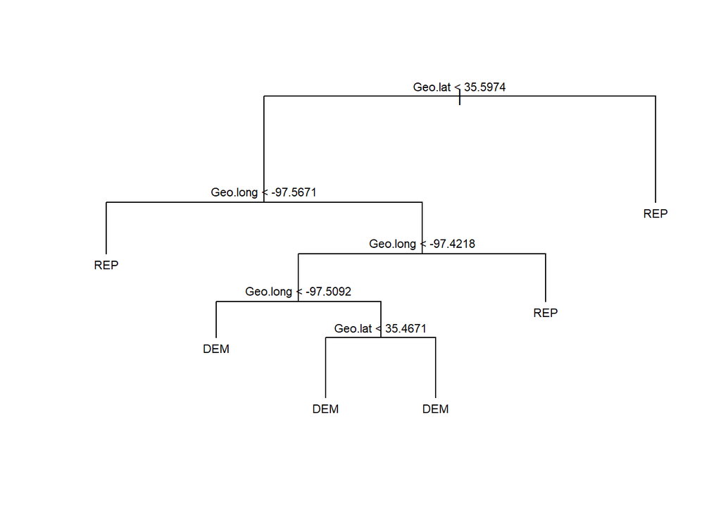

```r
set.seed(654987)
train <- sample(1:nrow(voteloc), 0.8*nrow(voteloc))
tree1 <- tree(PolitalAff ~ Status + Age + Geo.long + Geo.lat + Histage + HistMethod1, data = voteloc, subset = train)
plot(tree1)
treecv <- cv.tree(tree1)
text(tree1, cex = 0.7)
```

```r
probTree <- predict(tree1, voteloc[-train, ])
predtree <- apply(probTree, 1, which.max)
table(predtree, voteloc$PolitalAff[-train])
```

```
##
## predtree DEM IND LIB REP
##        1  86  13   0  80
##        4 122  26   0 253
```

Total Accuracy ~ 58%

The tree produced looked promising, but the accuracy was very low. The next step I took was to apply a random forest to see if the model could be improved.  
Note: The Libertarian level is dropped from the y variable because RF cannot handle empty levels in predictor variable

```r
set.seed(8675309)
voteloc$PolitalAffRF <- droplevels(voteloc$PolitalAff)
rf1 <- randomForest(PolitalAffRF ~ Status + Age + Geo.long + Geo.lat + VoterHist1 + HistMethod1,
                    data = voteloc, importance = TRUE, mtry = 6, ntree = 1000,
                    subset = train)
rfpreds <- predict(rf1, voteloc[-train, ])
table(rfpreds, voteloc$PolitalAff[-train])
```

```
##
## rfpreds DEM IND LIB REP
##     DEM 107  11   0  90
##     IND   2   1   0   1
##     REP  99  27   0 242
```

Total Accuracy ~ 60%  
Due to the high degree of flexibility needed to accurately fit this data, a Neural Network could be applicable.

```r
set.seed(666)

x <- model.matrix(PolitalAff ~ Status + Age + Geo.long + Geo.lat + Histage + HistMethod1, voteloc)

x_train <- x[train, ]
x_test <- x[-train, ]
y_train <- to_categorical(as.integer(voteloc[train, 7]))[, -1]
```

```
## Loaded Tensorflow version 2.5.0
```

```r
y_test <- to_categorical(as.integer(voteloc[-train, 7]))[, -1]

nn <- keras_model_sequential() %>%
  layer_dense(units = 256, activation = "relu", input_shape = ncol(x)) %>%
  layer_dropout(rate = 0.4) %>%
  layer_dense(units = 32, activation = "relu") %>%
  layer_alpha_dropout(rate = 0.2) %>%
  layer_dense(units = 16, activation = "relu") %>%
  layer_dropout(rate = 0.1) %>%
  layer_dense(units = 4, activation = "softmax")

nn %>%  compile(loss = "categorical_crossentropy",
              optimizer = optimizer_rmsprop(),
              metrics = "accuracy"
              )

history <- nn %>%
  fit(
    x_train,
    y_train,
    epochs = 50,
    batch_size = 250,
    validation_split = 0.25
  )

probnn <- predict(nn, x_test)
prednn <- apply(probnn, 1, which.max)
table(prednn, voteloc$PolitalAff[-train])
```

```
##
## prednn DEM IND LIB REP
##      4 208  39   0 333
```

Total Accuracy ~ 57%  
I’m unsure if my lack of experience with NN’s is showing, or if the application here is simply unsuited, but it seems my Neural Network has fallen into the single class prediction hole and refuses to come out no matter how much tuning I do.

As you can see, the Tree models only use the geographical location to predict registration, and looking at a plot it becomes obvious why.

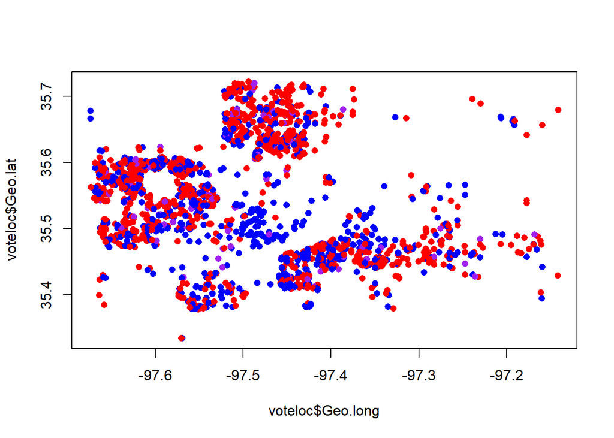

```r
color <- NULL
color[voteloc$PolitalAff == "DEM"] <- "blue"
color[voteloc$PolitalAff == "IND"] <- "purple"
color[voteloc$PolitalAff == "LIB"] <- "yellow"
color[voteloc$PolitalAff == "REP"] <- "red"
plot(voteloc$Geo.long, voteloc$Geo.lat, col = color, pch = 16)
```

If you are familiar with the layout of Oklahoma county, you may be able to pick out some regions like Oklahoma City in the middle group of blue dots. Hefner lake is the large swath of emptiness to the northwest and it seems that the farther from the city center you go, the more red the graph gets.

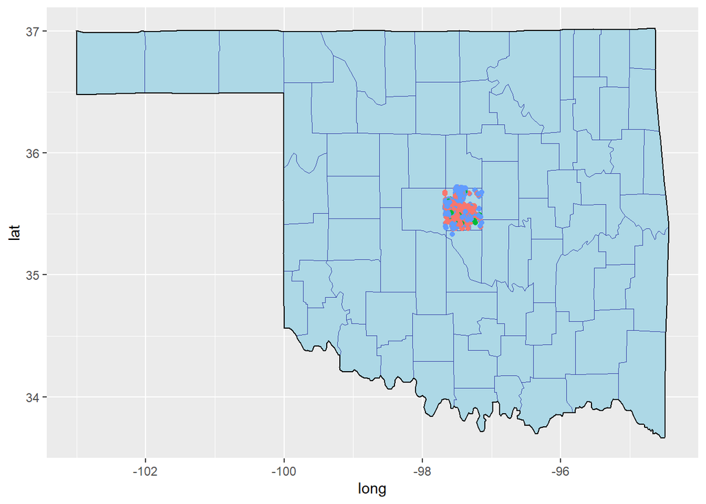

```r
OK <- map_data("state", region = "oklahoma")
OKcounties <- map_data("county", region = "oklahoma")

g <- ggplot() +
  geom_polygon( data=OKcounties, aes(x=long, y=lat, group=group),
                color="darkblue", fill="lightblue", size = .1 ) +
  geom_polygon( data=OK, aes(x=long, y=lat, group=group),
                color="black", fill="lightblue" , alpha = 0.3)

withdots <- g + geom_point(data = voteloc, aes(x = Geo.long, y = Geo.lat, colour = color), show.legend = FALSE)
withdots
```

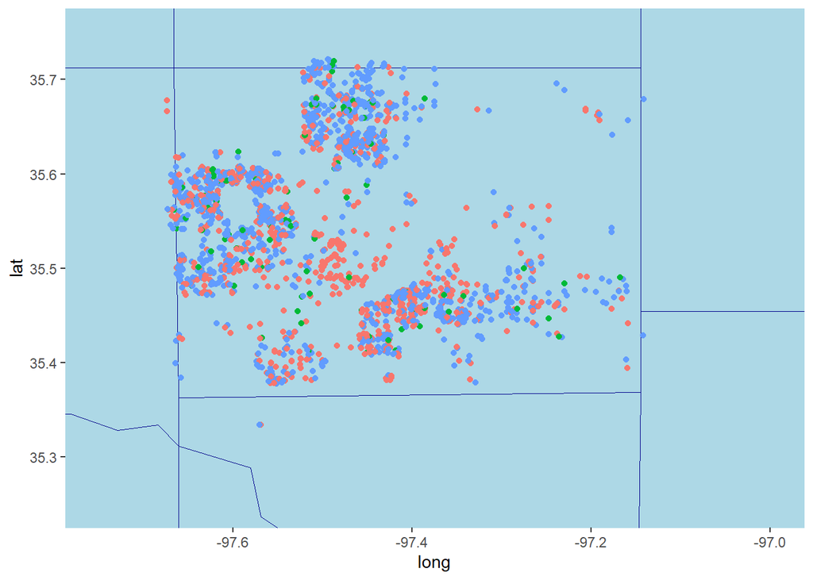

```r
zoomin <- withdots + coord_cartesian(xlim = c(-97.75, -97), ylim = c(35.25, 35.75))
zoomin
```

Here are the same points on a map of Oklahoma for scale. Keep in mind that the colors are reversed.

Lastly I thought that better results may be obtained with Boosting, however there is not currently a distribution in the gbm function to handle categorical variables with more than two options to my knowledge.

## Final Thoughts

```r
table(rfpreds, voteloc$PolitalAff[-train])
```

```
##
## rfpreds DEM IND LIB REP
##     DEM 107  11   0  90
##     IND   2   1   0   1
##     REP  99  27   0 242
```

The above confusion matrix is from the best model the chosen methods could produce, and while they may be interesting from an analytical point of view, I have to say I don’t think much use will come of them. The process of creating the models gleaned more information in that the main predictor of political affiliation in Oklahoma county was location.  
Even a highly Neural Network had trouble with the data I gave it, in future it seems that more data, or perhaps a more predictable outcome variable would produce a model with better predictive value. On the other hand, it may be the case that human behavior is a bit too random to expect a better predictive outcome than the one achieved with these models.